# Approximate Inference & Bayesian Classification

INFO 521 · Module 5 · Lecture B — Laplace Approximation & a Taste of Sampling

Greg Chism

College of Information Science · University of Arizona

August 2026

## Learning outcomes

By the end of Lecture B you should be able to:

1. **State the Laplace approximation** — a Gaussian at the MAP with the inverse Hessian as covariance — and derive its two ingredients.
2. **Connect it to the course through-line** — curvature = Fisher information.
3. **Explain the Metropolis idea** — why *ratios* of unnormalized posteriors suffice — and read a trace plot.
4. **Choose between them** — speed vs. shape-faithfulness.

## The problem, restated

From Lecture A: with a Gaussian prior on $\mathbf{w}$,

$$p(\mathbf{w} \mid \mathcal{D})
= \frac{e^{\ell(\mathbf{w})}\, p(\mathbf{w})}{p(\mathcal{D})}
\qquad\text{with}\qquad
p(\mathcal{D}) = \int e^{\ell(\mathbf{w})}\, p(\mathbf{w})\, d\mathbf{w}
\;\;\text{— intractable.}$$

We can **evaluate the numerator anywhere** — we just can’t integrate it. And integrals are exactly what Bayes needs: normalization, credible intervals, posterior predictives.

Today’s running example: hypertension vs. age on a **tiny real cohort** ($N = 25$ NHANES adults, seed 521) — small samples are where approximation quality actually matters.

## Idea 1 — Laplace: a Gaussian at the peak

Find the peak, match the curvature, call it Gaussian:

1. **Peak**: $\hat{\mathbf{w}}_{\text{MAP}} = \arg\max\ \log p(\mathbf{w}\mid\mathcal{D})$ — Newton, exactly as in Lecture A (one extra $-\mathbf{w}/\tau^2$ term).
2. **Curvature**: Taylor-expand $\log p(\mathbf{w}\mid\mathcal{D})$ to second order at the peak (the linear term vanishes there):

$$\boxed{\;
p(\mathbf{w} \mid \mathcal{D}) \;\approx\;
\mathcal{N}\!\left(\mathbf{w} \,\middle|\, \hat{\mathbf{w}}_{\text{MAP}},\ \mathbf{A}^{-1}\right),
\qquad
\mathbf{A} = -\,\nabla\nabla \log p(\mathbf{w}\mid\mathcal{D})\big|_{\hat{\mathbf{w}}_{\text{MAP}}}
\;}$$

A quadratic log-density **is** a Gaussian — Laplace simply *decrees* the quadratic approximation exact.

## The through-line closes

For our model the curvature matrix is

$$\mathbf{A} \;=\; \underbrace{\mathbf{X}^{\!\top}\mathbf{R}\,\mathbf{X}}_{\text{observed Fisher information}}
\;+\; \underbrace{\tfrac{1}{\tau^2}\mathbf{I}}_{\text{prior precision}}
\qquad
\mathbf{R} = \mathrm{diag}\bigl(\mu_n(1-\mu_n)\bigr)$$

The promise made in M1 is now fully kept — **one object, four appearances**:

| Module | Role of the curvature |
| --- | --- |
| M1 | $\mathbf{X}^{\!\top}\mathbf{X}$ invertible ⇒ unique $\hat{\mathbf{w}}$ |
| M3 | $-\tfrac{1}{\sigma^2}\mathbf{X}^{\!\top}\mathbf{X}$ = Hessian; $\mathcal{I}^{-1} = \mathrm{Cov}[\hat{\mathbf{w}}]$ |
| M4 | $\tfrac{1}{\sigma^2}\mathbf{X}^{\!\top}\mathbf{X}$ = the data’s precision in $\mathbf{S}_N^{-1}$ |
| M5 | $\mathbf{X}^{\!\top}\mathbf{R}\mathbf{X} + \tfrac{1}{\tau^2}\mathbf{I}$ = Laplace covariance$^{-1}$ |

## Laplace vs. the exact posterior, on real patients

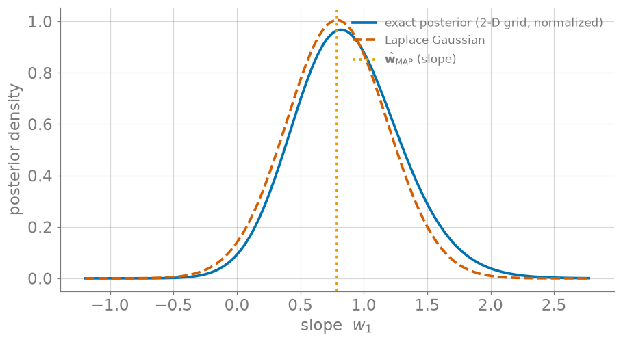

Figure 1: Slope marginal, N = 25 real patients: exact (grid-normalized, blue) vs. Laplace Gaussian (vermillion). Peak: matched. Tails: not.

## When the peak isn’t the story

Laplace is **local**: it sees the peak and its curvature — nothing else.

- **Skew** (previous slide): the Gaussian’s symmetric tails misprice probability precisely where risk lives.
- **Multimodality**: a second mode is invisible from the first one.
- It **sharpens with data**: as $N$ grows, posteriors Gaussian-ize (the m4b contraction), and Laplace converges on the truth — cheap and excellent at scale, risky at $N = 25$.

Wanted: a method whose error shrinks with *compute*, not with *assumptions*.

## Idea 2 — don’t approximate the shape; draw from it

If we had samples $\mathbf{w}^{(1)}, \dots, \mathbf{w}^{(S)} \sim p(\mathbf{w}\mid\mathcal{D})$, every integral becomes an average:

$$\mathbb{E}\bigl[f(\mathbf{w}) \mid \mathcal{D}\bigr]
\;\approx\; \frac{1}{S}\sum_{s=1}^{S} f\!\left(\mathbf{w}^{(s)}\right)$$

— intervals from sample quantiles, predictives by averaging $\sigma(\mathbf{w}^{(s)\top}\mathbf{x}_\ast)$, no normalizer ever computed.

**Monte Carlo** trades algebra for computation. The catch: how do you draw from a density you can’t even normalize?

## The Metropolis trick: ratios cancel the normalizer

Random-walk **Metropolis**, one step:

1. From the current $\mathbf{w}$, **propose** $\mathbf{w}' \sim \mathcal{N}(\mathbf{w},\ s^2\mathbf{I})$.
2. **Accept** with probability $\ \min\!\left(1,\ \dfrac{\tilde{p}(\mathbf{w}' \mid \mathcal{D})}{\tilde{p}(\mathbf{w} \mid \mathcal{D})}\right)$; otherwise stay.

$\tilde{p}$ is the **unnormalized** posterior — in the ratio, the unknown $p(\mathcal{D})$ **cancels**. The walk visits regions in proportion to their posterior mass.

Uphill moves: always taken. Downhill: sometimes — that “sometimes” is what makes it *explore* instead of *optimize*.

## Metropolis on the real cohort

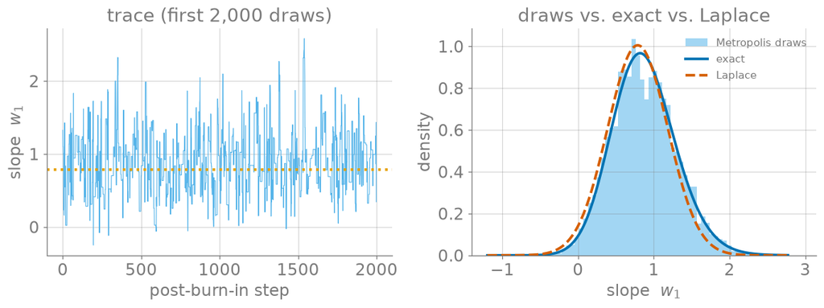

Figure 2: Metropolis, 24k steps (2k burn-in, seed 521): the draw histogram reproduces the exact skewed posterior — including the tail Laplace missed.

## Practicalities, in one slide

- **Burn-in** — early draws remember the start; discard them (we dropped 2,000).
- **Step size $s$** — too small: baby steps, slow coverage; too big: everything rejected. Tune toward moderate acceptance (~20–50%).
- **Correlation** — consecutive draws are not independent; effective sample size < $S$. More steps are cheap; *pretending* independence is not.
- Beyond this course: smarter proposals (gradients → Hamiltonian MC), multiple chains, convergence diagnostics.

## Choosing your approximation

|  | **Laplace** | **Metropolis (MCMC)** |
| --- | --- | --- |
| Cost | one Newton run | thousands of evaluations |
| Output | a Gaussian (formulas) | draws (averages, quantiles) |
| Error shrinks with… | more **data** | more **compute** |
| Fails when… | skew / multimodality | poor tuning, slow mixing |
| Use it for… | big-$N$ workhorse | small $N$, awkward shapes, audits |

In practice: **Laplace first**; sample when the answer matters in the tails — the two agreeing is itself evidence.

## Recap & bridge

- **Laplace**: $\mathcal{N}(\hat{\mathbf{w}}_{\text{MAP}}, \mathbf{A}^{-1})$; $\mathbf{A} = \mathbf{X}^{\!\top}\mathbf{R}\mathbf{X} + \tau^{-2}\mathbf{I}$ — the Fisher through-line, closed.
- **Metropolis**: propose–accept on *ratios*; the normalizer cancels; draws replace formulas.
- **Trade**: assumptions (Laplace) vs. compute (MCMC).

**Next (Module 6):** one last supervised idea — the *maximum-margin* classifier — and then the unsupervised turn: structure without labels.